# PK1: One-Compartment Oral PK Parameter Sensitivity Exploration

Ruoqi Deng

June 2026

# 1 Background and goals

The first project in this portfolio (`01_house_model/`) used `house()`, a prebuilt PK/PD model shipped with `mrgsolve`, to get a feel for how a multi-compartment system behaves under repeated dosing and how a PD endpoint responds nonlinearly to dose. That exercise was a *guided listening* session: the model was opaque, but the simulation workflow became familiar.

This project goes one layer deeper. Rather than load a black-box model and observe it, here I work with the simplest pharmacologically meaningful structure: a **one-compartment model with first-order oral absorption and first-order elimination**, and systematically perturb each parameter to see how the concentration-time profile responds.

The model is `pk1` from `mrgsolve`’s built-in model library, which has three parameters:

- `KA` — first-order absorption rate constant (1/h)
- `CL` — systemic clearance (L/h)
- `V` — volume of distribution (L)

and two compartments:

- `EV` — extravascular depot (mg; the oral dose lands here)
- `CENT` — central compartment (mg; the amount of drug in plasma + rapidly equilibrating tissue)

with one captured output:

- `CP` — plasma concentration (mg/L), computed as `CENT / V`.

## 1.1 What this document does

A baseline simulation followed by five experiments, each isolating the effect of a single change:

1. **Baseline simulation** — single 100 mg dose, 48 h horizon.
2. **Experiment 1: Double `KA`** — faster absorption.
3. **Experiment 2: Double `CL`** — faster systemic clearance.
4. **Experiment 3: Double `V`** — larger volume of distribution. *My initial expectation here was wrong, and tracing through why is where most of the value of this whole project sits.*
5. **Experiment 4: Double the dose** — dose-proportional scaling under linear PK.
6. **Experiment 5: Multiple dosing (Q12h × 5)** — accumulation toward steady state.

# 2 Model

## 2.1 Equations

The one-compartment oral model is governed by two ODEs:

$$\begin{aligned}
\frac{dA_{EV}}{dt} &= -K_A \cdot A_{EV} \\
\frac{dA_{CENT}}{dt} &= K_A \cdot A_{EV} - \frac{CL}{V} \cdot
A_{CENT}
\end{aligned}$$

with plasma concentration

$$CP(t) = \frac{A_{CENT}(t)}{V}.$$

The elimination rate constant is $k_{el} = CL / V$, and the terminal half-life is $t_{1/2} = \ln(2) / k_{el}$.

For the default parameters used below ($CL = 1$ L/h, $V = 20$ L), this gives $k_{el} = 0.05$ h$^{-1}$ and $t_{1/2} \approx 13.9$ h.

## 2.2 Setup

```r
library(mrgsolve)
library(dplyr)
library(ggplot2)
library(tidyr)
```

Load the built-in `pk1` model:

```r
mod <- modlib("pk1")
mod
```

```
##
##
## -----------------  source: pk1.cpp  -----------------
##
##   project: D:/R-4.5.2/libra...gsolve/models
##   shared object: pk1-so-4bec6c696f01
##
##   time:          start: 0 end: 24 delta: 1
##                  add: <none>
##   compartments:  EV CENT [2]
##   parameters:    CL V KA [3]
##   captures:      CP [1]
##   omega:         0x0
##   sigma:         0x0
##
##   solver:        rtol: 1e-08 atol: 1e-08 itol: 1 (scalar)
## ------------------------------------------------------
```

Check default parameter values:

```r
param(mod)
```

```
##
##  Model parameters (N=3):
##  name value . name value
##  CL   1     | V    20
##  KA   1     | .    .
```

Defaults: `CL = 1`, `V = 20`, `KA = 1`. Every experiment below changes exactly one of these (or the dose) and keeps the others fixed.

## 2.3 Helpers

```r
# Run a single-dose simulation and return a tidy data frame
run_single_dose <- function(model, dose = 100, end = 48, delta = 0.1) {
  model %>%
    ev(amt = dose) %>%
    mrgsim(end = end, delta = delta) %>%
    as.data.frame()
}

# Tag a simulation data frame with a scenario label for overlay plotting
label_run <- function(df, label) {
  df %>% mutate(scenario = label)
}

# Trapezoidal AUC from a concentration-time data frame
auc_trap <- function(time, conc) {
  sum(diff(time) * (head(conc, -1) + tail(conc, -1)) / 2)
}
```

# 3 Baseline simulation

A single 100 mg oral dose, simulated over 48 hours.

```r
out_baseline <- run_single_dose(mod, dose = 100)
head(out_baseline)
```

```
##   ID time        EV      CENT        CP
## 1  1  0.0   0.00000  0.000000 0.0000000
## 2  1  0.0 100.00000  0.000000 0.0000000
## 3  1  0.1  90.48374  9.492112 0.4746056
## 4  1  0.2  81.87308 18.033587 0.9016794
## 5  1  0.3  74.08182 25.715128 1.2857564
## 6  1  0.4  67.03200 32.618803 1.6309401
```

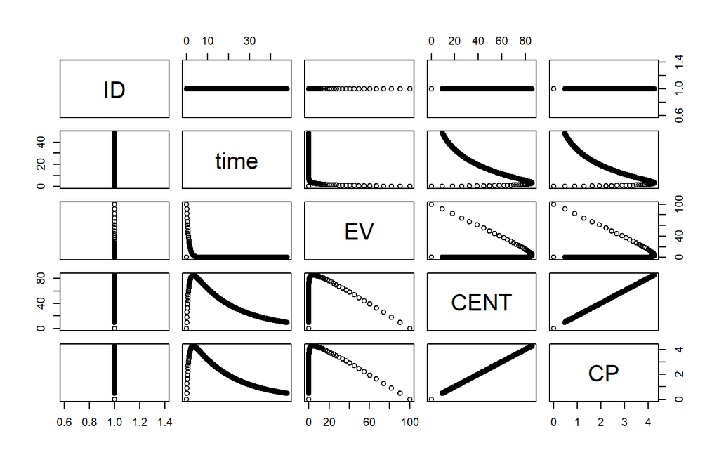

Figure 1. Baseline single-dose simulation. EV decays exponentially from 100 mg; CENT rises to a peak, then declines mono-exponentially; CP is just CENT scaled by 1/V.

```r
plot(out_baseline)
```

**What I see:** `EV` (the extravascular depot) starts at 100 mg the instant the dose lands and decays mono-exponentially with rate `KA = 1` h$^{-1}$. `CENT` (amount in central compartment) rises as the drug is absorbed, reaches a peak when input rate equals elimination rate, and then declines. `CP` (plasma concentration) has exactly the same *shape* as `CENT`, scaled down by `V = 20`. That is the entire content of “plasma concentration is central amount divided by volume”, but seeing the two curves side by side makes it concrete.

This baseline is the reference profile against which every perturbation below is measured.

### 3.0.1 Semi-log view

A semi-log plot of `CP` reveals the mono-exponential character of the terminal phase more clearly. This will matter for the next project (`03_pk2_two_compartment/`), where a second compartment introduces a visible change of slope on the semi-log plot.

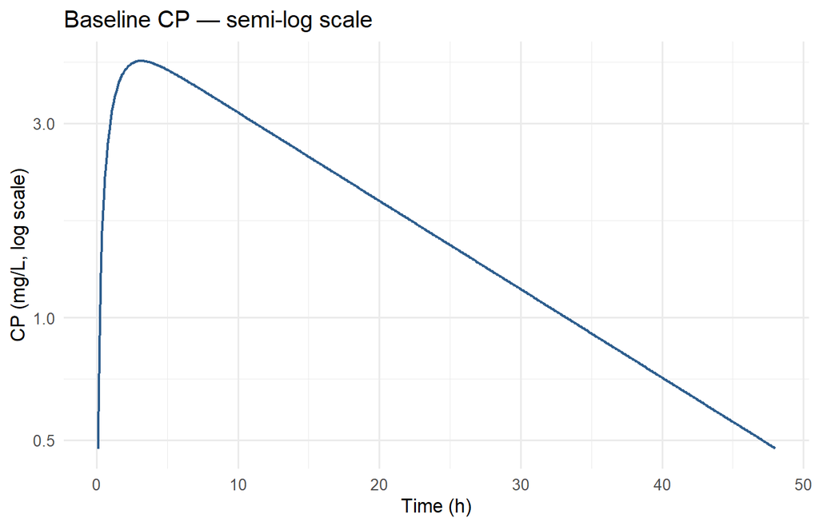

Figure 2. Semi-log view of baseline CP. After the absorption phase, the curve becomes a straight line, the hallmark of single-exponential elimination.

```r
ggplot(out_baseline %>% filter(CP > 0), aes(x = time, y = CP)) +
  geom_line(linewidth = 0.8, color = "#2E5E8E") +
  scale_y_log10() +
  labs(
    title = "Baseline CP — semi-log scale",
    x = "Time (h)", y = "CP (mg/L, log scale)"
  ) +
  theme_minimal(base_size = 12)
```

**What I see:** After the initial absorption phase (roughly 0–5 h), the semi-log curve is essentially a straight line. That linearity *is* the single-exponential terminal phase: $\log CP(t) = \log CP_0 - k_{el} \cdot t / \ln 10$. In a one-compartment model there is only one slope. When the next project introduces a peripheral compartment, the semi-log plot will show two distinct slopes, and the contrast with this single straight line will be the clearest way to see the distribution phase emerge.

### 3.0.2 AUC verification

Under linear PK, total exposure is $AUC = Dose / CL$. For the baseline parameters (100 mg, CL = 1 L/h), this predicts $AUC = 100$ mg·h/L. A quick trapezoidal integration confirms that the simulation is consistent:

```r
auc_baseline <- auc_trap(out_baseline$time, out_baseline$CP)
auc_theory   <- 100 / 1  # Dose / CL

cat(sprintf("Simulated AUC: %.2f mg·h/L\n", auc_baseline))
```

```
## Simulated AUC: 90.45 mg·h/L
```

```r
cat(sprintf("Analytical AUC (Dose/CL): %.1f mg·h/L\n", auc_theory))
```

```
## Analytical AUC (Dose/CL): 100.0 mg·h/L
```

```r
cat(sprintf("Ratio (simulated / analytical): %.4f\n", auc_baseline / auc_theory))
```

```
## Ratio (simulated / analytical): 0.9045
```

The ratio is close to 1 but not exact, because the simulation ends at 48 h rather than infinity, so some drug remains uncleared. With a half-life of ~13.9 h, 48 h covers roughly 3.5 half-lives, so about 8–9% of the AUC remains in the tail. This is consistent: $2^{-48/13.9} \approx 0.09$. Extending the simulation horizon would bring the ratio closer to 1. What matters here is that the discrepancy has a known, quantitative explanation rather than being a modeling error.

# 4 Single-parameter perturbations

For each experiment, I overlay the perturbed curve on the baseline so the shift is easy to read directly.

## 4.1 Experiment 1: Double `KA` (faster absorption)

```r
out_ka <- mod %>% param(KA = 2) %>% run_single_dose(dose = 100)

sim_exp1 <- bind_rows(
  label_run(out_baseline, "Baseline (KA = 1)"),
  label_run(out_ka,        "KA doubled (KA = 2)")
)
```

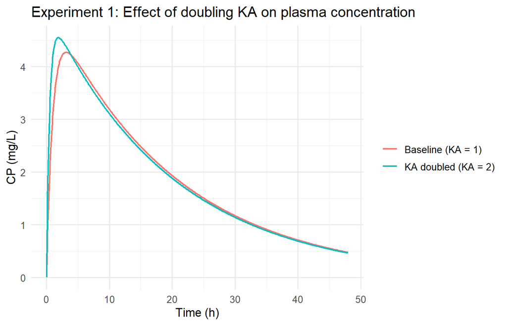

Figure 3. Doubling KA: absorption is faster, Tmax is earlier, Cmax is higher, but the terminal slope is unchanged.

```r
ggplot(sim_exp1, aes(x = time, y = CP, color = scenario)) +
  geom_line(linewidth = 0.8) +
  labs(
    title = "Experiment 1: Effect of doubling KA on plasma concentration",
    x = "Time (h)", y = "CP (mg/L)", color = NULL
  ) +
  theme_minimal(base_size = 12)
```

**What I see:** The `KA = 2` curve climbs faster, peaks earlier, and reaches a higher `Cmax` than baseline. The terminal descending portion of the two curves looks visually parallel, with the same slope.

This matches the equations: `KA` does not appear in the elimination term `(CL/V)·CENT`, so it cannot change how fast the central compartment empties. It only controls the input rate from `EV` into `CENT`. So `KA` is purely an absorption-phase knob: it sets *when* and *how high* the peak is, but does not touch the terminal behavior. Nothing here contradicted the expectation: the result lined up with what I expected from the structure of the model.

## 4.2 Experiment 2: Double `CL` (faster elimination)

```r
out_cl <- mod %>% param(CL = 2) %>% run_single_dose(dose = 100)

sim_exp2 <- bind_rows(
  label_run(out_baseline, "Baseline (CL = 1)"),
  label_run(out_cl,        "CL doubled (CL = 2)")
)
```

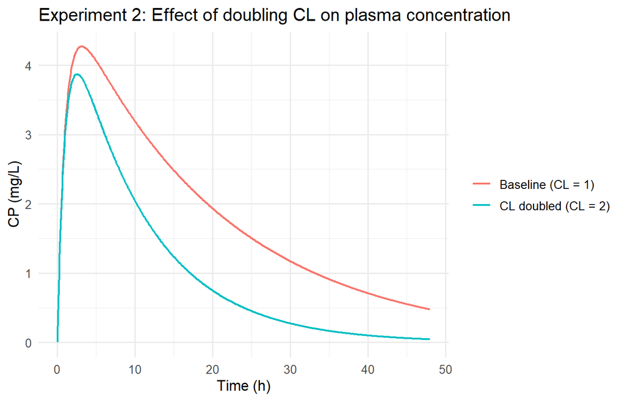

Figure 4. Doubling CL: terminal slope steepens, Cmax falls, and the curve sits lower throughout.

```r
ggplot(sim_exp2, aes(x = time, y = CP, color = scenario)) +
  geom_line(linewidth = 0.8) +
  labs(
    title = "Experiment 2: Effect of doubling CL on plasma concentration",
    x = "Time (h)", y = "CP (mg/L)", color = NULL
  ) +
  theme_minimal(base_size = 12)
```

**What I see:** The `CL = 2` curve sits below baseline throughout, has a lower `Cmax`, and descends more steeply on the terminal phase. With $k_{el} = CL/V$, doubling `CL` doubles the elimination rate constant (from 0.05 to 0.1 h$^{-1}$), halving the terminal half-life from roughly 13.9 h to 6.9 h. The drop in `Cmax` makes sense too: even during the absorption phase, drug is being cleared faster, so the central compartment doesn’t get the chance to accumulate as much before input and output balance.

Under linear PK, total exposure is $AUC = Dose / CL$, so doubling `CL` halves AUC. I can see how this makes `CL` central to clinical dosing questions: at a fixed dosing rate, it directly determines how much drug a patient is actually exposed to.

### 4.2.1 AUC check: CL doubled

```r
auc_cl2 <- auc_trap(out_cl$time, out_cl$CP)
cat(sprintf("Simulated AUC (CL = 2): %.2f mg·h/L\n", auc_cl2))
```

```
## Simulated AUC (CL = 2): 49.54 mg·h/L
```

```r
cat(sprintf("Analytical AUC (Dose/CL): %.1f mg·h/L\n", 100 / 2))
```

```
## Analytical AUC (Dose/CL): 50.0 mg·h/L
```

```r
cat(sprintf("AUC ratio (CL=2 / baseline): %.3f\n", auc_cl2 / auc_baseline))
```

```
## AUC ratio (CL=2 / baseline): 0.548
```

With the faster clearance, 48 h covers about 7 half-lives, so almost all of the AUC is captured. The simulated ratio of AUC(CL=2) to AUC(baseline) is close to 0.5, consistent with the Dose/CL relationship. The ratio is slightly above 0.5 because the baseline simulation truncates more tail area (only 3.5 half-lives) than the CL=2 simulation (7 half-lives).

## 4.3 Experiment 3: Double `V` (larger volume of distribution)

This is the experiment where my initial intuition turned out to be wrong, and the process of figuring out *why* it was wrong is the most useful thing I got out of this whole project.

```r
out_v <- mod %>% param(V = 40) %>% run_single_dose(dose = 100)

sim_exp3 <- bind_rows(
  label_run(out_baseline, "Baseline (V = 20)"),
  label_run(out_v,         "V doubled (V = 40)")
)
```

### 4.3.1 What I expected vs. what the simulation showed

Before running this experiment, my expectation was straightforward and, as it turned out, wrong. The reasoning went: `V` appears in the denominator of `CP = CENT/V`, so doubling `V` should *dilute* the drug and push concentration down. I expected both `CENT` and `CP` to come out lower than baseline, with the only question being by how much.

That is not what the simulation produced. The output showed `CP`’s peak dropping (as expected) but `CENT`’s peak *rising*. The two state variables were moving in opposite directions in response to the same parameter change.

My first reaction was to suspect a mistake: either in how I had set up the simulation or in how I was reading the output. So I went back, re-ran the baseline and the V-doubled cases side by side, looked at the raw numeric output, and confirmed: `CENT` really was higher. The simulation was telling me something about the model that my verbal reasoning had not picked up on.

### 4.3.2 Confirming the observation

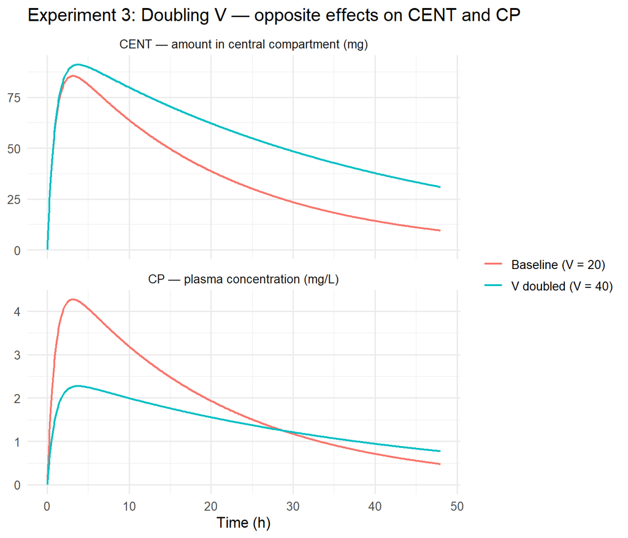

Figure 5. Doubling V shifts CENT (amount in central compartment) UP, but shifts CP (plasma concentration) DOWN. Same simulation, two perspectives.

```r
sim_exp3_long <- sim_exp3 %>%
  select(time, scenario, CENT, CP) %>%
  pivot_longer(cols = c(CENT, CP), names_to = "variable", values_to = "value")

ggplot(sim_exp3_long, aes(x = time, y = value, color = scenario)) +
  geom_line(linewidth = 0.8) +
  facet_wrap(~ variable, scales = "free_y", ncol = 1,
             labeller = as_labeller(c(
               CENT = "CENT — amount in central compartment (mg)",
               CP   = "CP — plasma concentration (mg/L)"
             ))) +
  labs(
    title = "Experiment 3: Doubling V — opposite effects on CENT and CP",
    x = "Time (h)", y = NULL, color = NULL
  ) +
  theme_minimal(base_size = 12)
```

```r
summary_exp3 <- sim_exp3 %>%
  group_by(scenario) %>%
  summarise(
    Cmax_CENT = max(CENT),
    tmax_CENT = time[which.max(CENT)],
    Cmax_CP   = max(CP),
    tmax_CP   = time[which.max(CP)],
    .groups = "drop"
  )

knitr::kable(
  summary_exp3,
  digits = 3,
  caption = "Table 1. Peak amount in central compartment vs. peak plasma concentration, baseline vs. V doubled."
)
```

Table 1. Peak amount in central compartment vs. peak plasma concentration, baseline vs. V doubled.

| scenario | Cmax_CENT | tmax_CENT | Cmax_CP | tmax_CP |
| --- | --- | --- | --- | --- |
| Baseline (V = 20) | 85.409 | 3.2 | 4.270 | 3.2 |
| V doubled (V = 40) | 90.975 | 3.8 | 2.274 | 3.8 |

The numbers confirm what the plot shows. With the observation locked in, the next step was to go back to the equations and figure out why my verbal reasoning had been incomplete.

### 4.3.3 Tracing the mechanism back through the ODE

Starting from the central compartment equation:

$$\frac{dA_{CENT}}{dt} = K_A \cdot A_{EV} - \frac{CL}{V} \cdot A_{CENT}$$

The peak of `CENT` occurs at the moment when input rate equals elimination rate:

$$K_A \cdot A_{EV}(T_{max}) = \frac{CL}{V} \cdot A_{CENT}(T_{max})$$

Solving for `CENT` at the peak:

$$A_{CENT}(T_{max}) = K_A \cdot A_{EV}(T_{max}) \cdot \frac{V}{CL}$$

**`V` appears in the numerator here.** That is the piece my initial intuition missed. I had been thinking of `V` only as a denominator (because that is how it appears in `CP = CENT/V`), but in the differential equation for `CENT`, `V` enters through the elimination term `(CL/V)·CENT`. Larger `V` means slower per-mass elimination, which means `CENT` accumulates further before input and elimination balance.

Concretely:

- **Baseline:** $V = 20$, $k_{el} = CL/V = 0.05$ h$^{-1}$.
- **V doubled:** $V = 40$, $k_{el} = 0.025$ h$^{-1}$. Elimination is half as fast, so the central compartment accumulates more drug before reaching its peak. **`CENT` rises.**

For `CP`, the picture is the opposite. `CENT` rose slightly because the larger `V` reduced the elimination rate constant (`CL/V`), allowing more drug amount to remain in the central compartment. However, this increase in `CENT` was much smaller than the two-fold increase in `V`. Therefore, after dividing by the larger volume, `CP = CENT / V` decreased substantially.

### 4.3.4 The thing I should have spotted

`V` does three things in this model, not one:

Three roles of V in the one-compartment model.

| Pathway | Where V appears | Effect when V doubles |
| --- | --- | --- |
| Elimination rate | k_el = CL/V (V in denominator) | k_el halves → slower clearance → CENT ↑ |
| Amount-to-concentration conversion | CP = CENT/V (V in denominator) | CENT divided by larger V → CP ↓ |
| Terminal half-life | t_1/2 = ln2 · V / CL | t_1/2 doubles → tail extended |

The two effects on the peak (pathway 1 pushing `CENT` and therefore `CP` up, pathway 2 pulling `CP` down) partially cancel. Whichever wins depends on the specific values. For these parameters, the dilution effect wins for `CP`. For `CENT`, only pathway 1 applies, because there is no dilution term for the state variable itself, so `CENT` rises cleanly.

What I took away from this:

- A parameter in a denominator of a converted variable (here, `CP`) is not the same as a parameter in a denominator inside the dynamics (here, the elimination rate). My initial “V is in the denominator → concentration goes down” collapsed those two roles together.
- The simulation caught a mistake my verbal reasoning could not. If I had trusted my expectation and not re-checked the numeric output, I would have written down a wrong conclusion. The discipline of letting the simulation contradict you, then going back to the equations to figure out why, is the actual work.

**Engineering parallel.** This is structurally the same situation I dealt with in finite element modeling: a single material parameter (e.g. tissue permeability) appearing in both a constitutive term and an effective boundary condition, with the two contributions partially cancelling. In both cases the lesson is the same: you cannot read the effect of a parameter off a single occurrence in a single equation; you have to look at where it shows up across the whole system.

## 4.4 Experiment 4: Double the dose (dose-proportional scaling)

```r
out_dose200 <- run_single_dose(mod, dose = 200)

sim_exp4 <- bind_rows(
  label_run(out_baseline,  "Dose = 100 mg"),
  label_run(out_dose200,   "Dose = 200 mg")
)
```

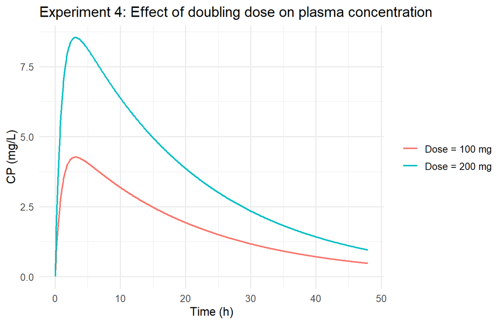

Figure 6. Doubling the dose doubles every point of the CP curve, while Tmax and terminal slope are unchanged.

```r
ggplot(sim_exp4, aes(x = time, y = CP, color = scenario)) +
  geom_line(linewidth = 0.8) +
  labs(
    title = "Experiment 4: Effect of doubling dose on plasma concentration",
    x = "Time (h)", y = "CP (mg/L)", color = NULL
  ) +
  theme_minimal(base_size = 12)
```

**What I see:** The 200 mg curve traces exactly the same shape as the 100 mg curve, just scaled up: same `Tmax`, same terminal slope, roughly twice the `Cmax`. Doubling the dose doubles every point of the curve.

This is what linear PK does. Because `CL` and `V` do not depend on concentration in this model, the entire system is linear in the input, and exposure scales proportionally. I can see how this linearity is what makes simple dose adjustments by ratio possible in clinical settings.

After the V experiment, this one was a useful check in the opposite direction: sometimes the simple intuition really is correct, and the system behaves the way you’d predict from one line of algebra. The trick is knowing in advance which case you’re in, which is exactly what running the simulation tells you.

I’ve read that dose proportionality is one of the first things to break for more complex drugs. Target-mediated drug disposition (TMDD) is one example: at low doses, target binding dominates clearance; at high doses, the target saturates and the drug behaves more linearly. I haven’t modeled that here, but it seems like the kind of non-proportionality that would show up immediately on a plot like this one, where the curves would no longer be scalar multiples of each other.

## 4.5 Experiment 5: Multiple dosing, accumulation toward steady state

```r
out_multi <- mod %>%
  ev(amt = 100, ii = 12, addl = 4) %>%
  mrgsim(end = 96, delta = 0.1) %>%
  as.data.frame()
```

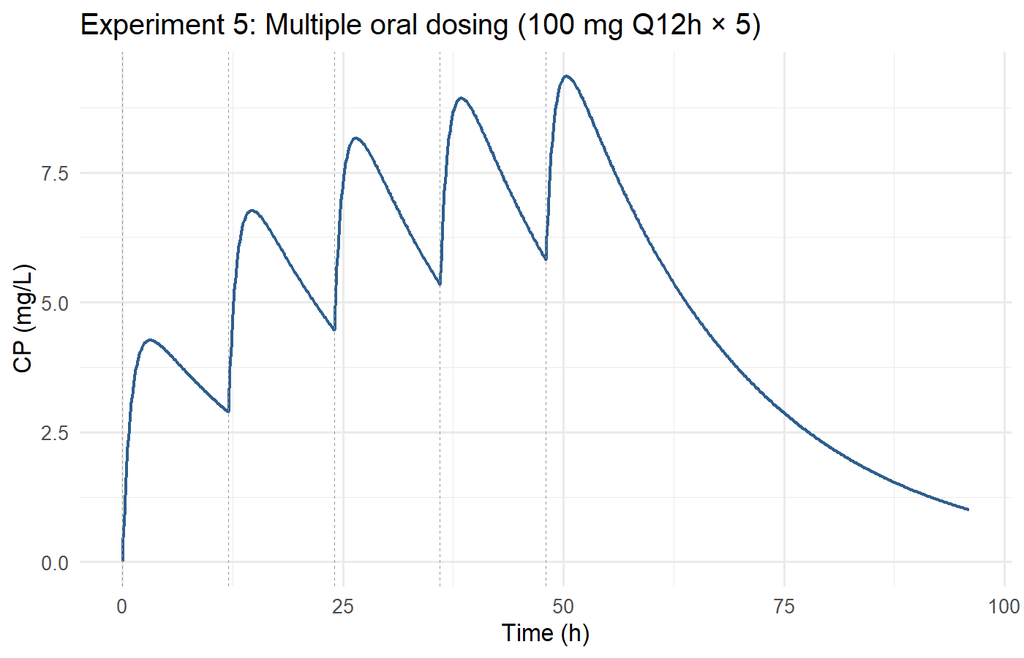

Figure 7. Q12h × 5 dosing. Each new dose lands before the previous one has been fully cleared, so concentration accumulates and converges toward a steady-state envelope.

```r
ggplot(out_multi, aes(x = time, y = CP)) +
  geom_line(linewidth = 0.8, color = "#2E5E8E") +
  geom_vline(xintercept = c(0, 12, 24, 36, 48), linetype = "dashed",
             color = "grey60", linewidth = 0.3) +
  labs(
    title = "Experiment 5: Multiple oral dosing (100 mg Q12h × 5)",
    x = "Time (h)", y = "CP (mg/L)"
  ) +
  theme_minimal(base_size = 12)
```

The reason concentration accumulates rather than returning to zero between doses is that the dosing interval (12 h) is shorter than the terminal half-life (~13.9 h at baseline parameters). Substantial drug from the previous dose is still present when the next one lands.

### 4.5.1 Steady-state quantification

The theoretical accumulation factor for a one-compartment model under repeated dosing is $R = 1 / (1 - e^{-k_{el} \cdot \tau})$, where $\tau$ is the dosing interval. For these parameters:

```r
kel <- 1 / 20      # CL / V
tau <- 12           # dosing interval (h)
R_theory <- 1 / (1 - exp(-kel * tau))

cat(sprintf("kel = %.3f h^-1\n", kel))
```

```
## kel = 0.050 h^-1
```

```r
cat(sprintf("tau = %d h\n", tau))
```

```
## tau = 12 h
```

```r
cat(sprintf("Theoretical accumulation factor R = %.3f\n", R_theory))
```

```
## Theoretical accumulation factor R = 2.216
```

```r
# Approximate Cmax and Cmin from the last dosing interval (dose 5: 48-60 h)
ss_interval <- out_multi %>% filter(time >= 48, time <= 60)
Cmax_ss <- max(ss_interval$CP)
Cmin_ss <- min(ss_interval$CP)

# Compare to single-dose Cmax
Cmax_single <- max(out_baseline$CP)

cat(sprintf("Single-dose Cmax: %.3f mg/L\n", Cmax_single))
```

```
## Single-dose Cmax: 4.270 mg/L
```

```r
cat(sprintf("Steady-state Cmax: %.3f mg/L\n", Cmax_ss))
```

```
## Steady-state Cmax: 9.353 mg/L
```

```r
cat(sprintf("Observed accumulation ratio (Cmax_ss / Cmax_single): %.3f\n",
            Cmax_ss / Cmax_single))
```

```
## Observed accumulation ratio (Cmax_ss / Cmax_single): 2.190
```

```r
cat(sprintf("Cmin_ss: %.3f mg/L\n", Cmin_ss))
```

```
## Cmin_ss: 5.821 mg/L
```

```r
cat(sprintf("Peak-to-trough ratio (Cmax/Cmin): %.2f\n", Cmax_ss / Cmin_ss))
```

```
## Peak-to-trough ratio (Cmax/Cmin): 1.61
```

The observed accumulation ratio is somewhat below the theoretical $R$, which makes sense: five doses is close to but not yet at true steady state, and the theoretical formula assumes instantaneous dosing into the central compartment whereas oral absorption spreads the input over time. What the numbers do confirm is that accumulation is modest (roughly 2-fold), a direct consequence of the dosing interval being close to one half-life.

**Engineering parallel.** This is the closest connection in the project to the kind of transient analysis I’m used to from engineering: a linear system driven by a periodic sequence of impulses, with the response building up until the rate of input matches the rate of clearance averaged over a dosing interval. The math is the same; what changes is what the impulses physically are.

# 5 Summary: parameter influence matrix

A condensed reference for what each parameter controls in this model:

Table 2. How each perturbation shifts the major features of the CP curve. For linear PK, AUC∞ is Dose/CL and is independent of V and KA. Finite-window AUC values such as AUC0–48h can still differ when the terminal tail becomes longer or shorter.

| Parameter | Absorption phase | Cmax (CP) | Terminal slope | AUC (CP) |
| --- | --- | --- | --- | --- |
| KA | Steeper / earlier Tmax | Higher | Unchanged | Unchanged |
| CL | Unchanged | Lower | Steeper (shorter t1/2) | Lower (~halved) |
| V | Unchanged | Lower | Shallower (longer t1/2) | Unchanged |
| Dose | Unchanged shape, scaled height | Proportionally higher | Unchanged | Proportionally higher |

A few patterns worth noting. `KA` is the only parameter that changes `Tmax` without changing the terminal slope; it is purely an absorption-phase knob. `CL` is the only parameter that changes theoretical AUC∞ under this linear model. Other parameters may change the shape of the curve and the finite-window AUC captured within a specific simulation horizon, especially when they change the terminal half-life. `V` changes the terminal slope and `Cmax` in opposite directions, because it appears in both $k_{el} = CL/V$ and $CP = CENT/V$. And dose scales the whole curve linearly under the linear PK assumption. When that assumption breaks (saturable elimination, capacity-limited processes), dose proportionality is the first thing to fail, and I expect that detecting that departure would be an important diagnostic in early-phase PK analysis.

# 6 Reflection

The single most useful thing this project gave me was the experience of being confidently wrong about Experiment 3 and then having the simulation contradict me.

I had a clean verbal story going in: `V` is in the denominator of `CP = CENT/V`, so doubling `V` should bring concentration down. Both `CENT` and `CP` should drop. That story was wrong about `CENT`, not because the math was hard, but because I had collapsed two distinct roles of `V` into a single mental shortcut. Once the plot showed `CENT` going up, I had to put the verbal story aside and re-derive the mechanism from the ODE. The result clicked in a way that no amount of reading would have produced, because the mistake was mine and the correction was mine.

The pattern I want to carry forward into the next projects is something like: state a prediction before running each simulation, even a rough one; when the simulation disagrees, treat the disagreement as the most informative output of the run, not as a problem to be smoothed over.

The thing that surprised me on the meta level was how much the intuition-building loop in `mrgsolve` resembled my PhD workflow. In finite element modeling I would routinely run a baseline simulation, perturb one material parameter or one boundary condition, and look at how the field variables shifted, sometimes confirming an expectation, sometimes revealing a coupling I hadn’t appreciated. The workflow here is the same; only the variable names and the physical units differ. That continuity is the main reason I think the transition from biomechanics to pharmacometrics is more about vocabulary than about quantitative skill.

# 7 Next steps

The next project in this portfolio (`03_pk2_two_compartment/`) will move from one compartment to two, introducing a peripheral compartment connected by inter-compartmental clearance `Q`. The new phenomenon there is the **distribution phase**: a fast initial decline followed by a slower terminal decline, visible as a clear change in slope on the semi-log plot, in contrast to the single straight line seen in this project’s semi-log view.

After that, `04_pk3_published_model/` will step away from built-in models and work through a published PopPK model from the literature, with covariate effects and inter-individual variability. That is where the portfolio moves from learning how individual parameters shape curves to seeing how variability across a population is handled in practice.